# Notebook

### Web Information Retrieval and Data Mining - Assignment 3

```
Student: Jacobsen, Anik (1519077)
```

#### Answer 1.1, Baseline (4p)

- Dense network, at least 3 layers, shaped like a pyramid
  - Last layer: 10 nodes, sigmoid.
  - Loss: categorical cross-entropy. Metric: accuracy
- No preprocessing, regularization. Get at least 70% accuracy.
- Explain design decisions. Discuss performance.
  - Does it overfit (large/growing gap between loss and val_loss)?

[output not shown]

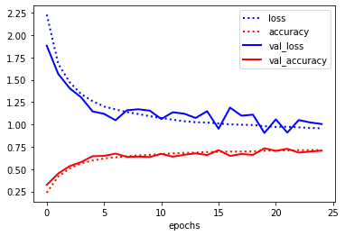

```
Model: "sequential_11"
_________________________________________________________________
Layer (type)                 Output Shape              Param #
=================================================================
reshape_8 (Reshape)          (None, 3072)              0
_________________________________________________________________
dense_42 (Dense)             (None, 3072)              9440256
_________________________________________________________________
dense_43 (Dense)             (None, 768)               2360064
_________________________________________________________________
dense_44 (Dense)             (None, 384)               295296
_________________________________________________________________
dense_45 (Dense)             (None, 192)               73920
_________________________________________________________________
dense_46 (Dense)             (None, 10)                1930
=================================================================
Total params: 12,171,466
Trainable params: 12,171,466
Non-trainable params: 0
_________________________________________________________________
None
def build_model_1_1():

  model = models.Sequential()

  model.add(layers.Reshape((3072,), input_shape=(32,32,3)))

  model.add(layers.Dense(3072, activation='relu'))
  model.add(layers.Dense(768, activation='relu'))
  model.add(layers.Dense(384, activation='relu'))
  model.add(layers.Dense(192, activation='relu'))
  model.add(layers.Dense(10, activation='softmax'))

  model.compile(optimizer='rmsprop',
                loss='categorical_crossentropy',
                metrics=['accuracy'])

  return model
```

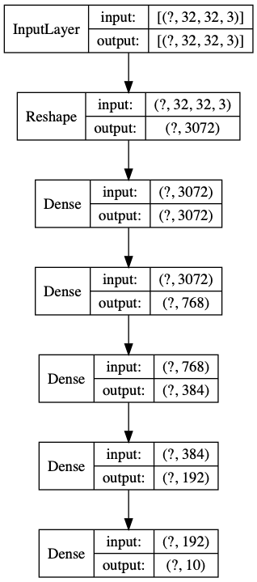

#### Answer 1.2, Preprocess (2p)

- Convert images to greyscale, other preprocessing optional.
  - Input shape should be (32,32,1)
- Explain design decisions. Is it better? Why (not)?
  - Color information is likely not so useful for classification. Greyscale makes the network smaller, less parameters to learn, less likely to overfit.

[output not shown]

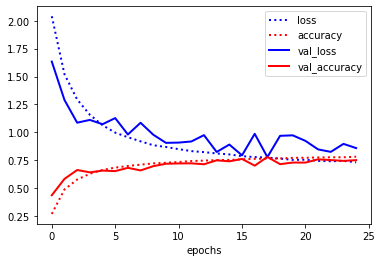

```
Model: "sequential_12"
_________________________________________________________________
Layer (type)                 Output Shape              Param #
=================================================================
reshape_12 (Reshape)         (None, 1024)              0
_________________________________________________________________
dense_53 (Dense)             (None, 1024)              1049600
_________________________________________________________________
dense_54 (Dense)             (None, 256)               262400
_________________________________________________________________
dense_55 (Dense)             (None, 128)               32896
_________________________________________________________________
dense_56 (Dense)             (None, 64)                8256
_________________________________________________________________
dense_57 (Dense)             (None, 10)                650
=================================================================
Total params: 1,353,802
Trainable params: 1,353,802
Non-trainable params: 0
_________________________________________________________________
None
def build_model_1_2():
  n_layer1 = 1024
  n_layer2 = 1024/4
  n_layer3 = 1024/8
  n_layer4 = 1024/16

  model = models.Sequential()

  model.add(layers.Reshape((1024,), input_shape=(32,32,1)))

  model.add(layers.Dense(n_layer1, activation='relu'))
  model.add(layers.Dense(n_layer2, activation='relu'))
  model.add(layers.Dense(n_layer3, activation='relu'))
  model.add(layers.Dense(n_layer4, activation='relu'))
  model.add(layers.Dense(10, activation='softmax'))

  model.compile(optimizer='rmsprop',
                loss='categorical_crossentropy',
                metrics=['accuracy'])

  return model
```

#### Answer 1.3, Tune (4p)

- Regularize the model. What works best?
  - Should consider batch normalization, dropout, l1/l2 regularization (or Nesterov)
- Tune other hyperparameters (e.g. learning rate, batch size,...) as you see fit.
  - At least consider tuning learning rate, ideally also momentum, decay, other optimizers
- Explain your findings and final design decisions. Discuss the results.
  - Should be better, at least it shouldn't overfit

[output not shown]

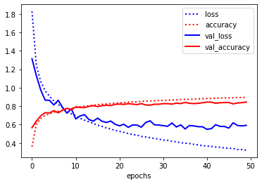

```
def build_model_1_3():

    n_layer1 = 1024
    n_layer2 = 1024/4
    n_layer3 = 1024/8
    n_layer4 = 1024/16

    model = models.Sequential()
    model.add(layers.Reshape((1024,), input_shape=(32,32,1)))
    model.add(layers.Dense(n_layer1, activation='relu'))
    model.add(layers.Dense(n_layer2, activation='relu'))
    model.add(layers.Dense(n_layer3, activation='relu'))
    model.add(layers.Dense(n_layer4, activation='relu'))
    model.add(layers.Dropout(0.2))
    model.add(layers.Dense(10, activation='softmax'))

    #adam = tf.keras.optimizers.Adam(learning_rate=0.001, beta_1=0.9, beta_2=0.999, amsgrad=True)

    sgd = tf.keras.optimizers.SGD(lr=0.01, decay=1e-6, momentum=0.9, nesterov=True)

    model.compile(optimizer=sgd,
                  loss='categorical_crossentropy',
                  metrics=['accuracy'])
    return model
```

#### Answer 2.1, ConvNet (7p)

- Build a sequential ConvNet, get at least 90% accuracy.
  - Conv2D layers, input shape (32,32,1)
  - Consider using blocks of Conv2D layers with maxpooling in between
  - Use zero-padding in Conv2D layers because the images are small
  - At least one dense hidden layer and dense output layer (sigmoid)
  - Consider adding batch normalization, dropout
  - Consider small dropout rates in beginning, larger dropout rates later in network
  - Consider other optimizers and tuning learning rate, momentum,...
- Explain what you did and why (800 chars). Is it working well?
  - Should be quite elaborate and sensible

[output not shown]

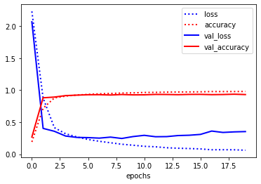

```
Model: "sequential_48"
_________________________________________________________________
Layer (type)                 Output Shape              Param #
=================================================================
conv2d_54 (Conv2D)           (None, 32, 32, 32)        320
_________________________________________________________________
conv2d_55 (Conv2D)           (None, 32, 32, 32)        9248
_________________________________________________________________
max_pooling2d_18 (MaxPooling (None, 16, 16, 32)        0
_________________________________________________________________
conv2d_56 (Conv2D)           (None, 16, 16, 64)        18496
_________________________________________________________________
conv2d_57 (Conv2D)           (None, 16, 16, 64)        36928
_________________________________________________________________
max_pooling2d_19 (MaxPooling (None, 8, 8, 64)          0
_________________________________________________________________
conv2d_58 (Conv2D)           (None, 8, 8, 128)         73856
_________________________________________________________________
conv2d_59 (Conv2D)           (None, 8, 8, 128)         147584
_________________________________________________________________
flatten_9 (Flatten)          (None, 8192)              0
_________________________________________________________________
dense_194 (Dense)            (None, 128)               1048704
_________________________________________________________________
dropout_21 (Dropout)         (None, 128)               0
_________________________________________________________________
dense_195 (Dense)            (None, 256)               33024
_________________________________________________________________
dense_196 (Dense)            (None, 10)                2570
=================================================================
Total params: 1,370,730
Trainable params: 1,370,730
Non-trainable params: 0
_________________________________________________________________
None
def build_model_2_1():

    #input_shape = (32,32,1)
    model = models.Sequential()

    model.add(layers.Conv2D(32, (3, 3), activation='relu', padding='same', input_shape=(32, 32, 1)))
    model.add(layers.Conv2D(32, (3, 3), activation='relu', padding='same'))
    model.add(layers.MaxPooling2D((2, 2)))
    model.add(layers.Conv2D(64, (3, 3), activation='relu', padding='same'))
    model.add(layers.Conv2D(64, (3, 3), activation='relu', padding='same'))
    model.add(layers.MaxPooling2D((2, 2)))
    model.add(layers.Conv2D(128, (3, 3), activation='relu', padding='same'))
    model.add(layers.Conv2D(128, (3, 3), activation='relu', padding='same'))
    model.add(layers.Flatten())
    model.add(layers.Dense(128, activation='relu'))
    model.add(layers.Dropout(0.5))
    model.add(layers.Dense(256, activation='relu'))
    model.add(layers.Dense(10, activation='softmax'))

    sgd = tf.keras.optimizers.SGD(lr=0.01, momentum=0.9, nesterov=True)
    # adam = tf.keras.optimizers.Adam(learning_rate=0.01, beta_1=0.9, beta_2=0.999, amsgrad=True)

    model.compile(optimizer=sgd,
                  loss='categorical_crossentropy',
                  metrics=['accuracy'])
    return model
```

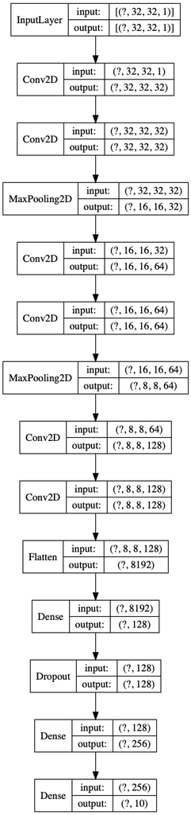

#### Answer 2.2, Data Augmentation (3p)

- Augment the preprocessed training data.
  - Use small variations (small shifts up-down, left-right) of flips becasue the images are small
  - Large shifts and rotations distort the image too much
- Explain what you did and why. Discuss the performance of the model.

[output not shown]

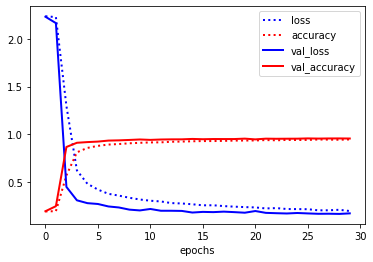

```
image_gen = ImageDataGenerator(width_shift_range=0.1, height_shift_range=0.1, rotation_range=10, zoom_range=0.2, fill_mode= "nearest")
```

#### Answer 3.1, Misclassifications (2p)

[output not shown]

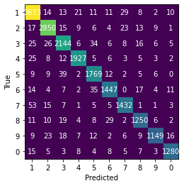

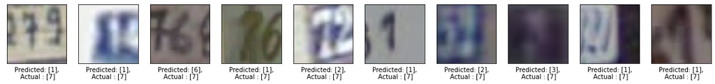

#### Answer 3.2, Activations (4p)

- Retrieve and visualize the activations for one example
- For every filter for different convolutional layers (at different depths in the network).
- Give an explanation. Is your model indeed learning something useful?
  - Should detect edges etc in first layers, higher-order object (e.g. interesting regions) in deeper layers.

[output not shown]

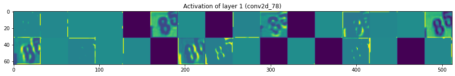

#### Answer 3.3, Class activation map (4p)

- Show a class activation map for your last convolutional layer
- Superimpose the activation map over the image, or plot side by side
  - Should make sense, detect interesting regions to classify the number

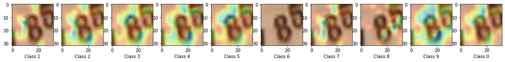

```
def plot_3_3():

  first_image = rgb2gray(X_test)[0]
  first_image = np.expand_dims(first_image, axis=0)

  model = load_model_from_file(base_dir, "model_2_2")

  fig, axes = plt.subplots(1, 10,  figsize=(20, 10))

  for c in range(10):
    class_eight_output = model.output[:, c]

    last_conv_layer = model.get_layer(index=6)
    grads = K.gradients(class_eight_output, last_conv_layer.output)[0]

    pooled_grads = K.mean(grads, axis=(0, 1, 2))

    iterate = K.function([model.input], [pooled_grads, last_conv_layer.output[0]])

    pooled_grads_value, conv_layer_output_value = iterate([first_image])

    for i in range(128):
      conv_layer_output_value[:, :, i] *= pooled_grads_value[i]

    heatmap = np.mean(conv_layer_output_value, axis=-1)
    heatmap = np.maximum(heatmap, 0)
    heatmap /= np.max(heatmap)

    # We resize the heatmap to have the same size as the original image
    heatmap = cv2.resize(heatmap, (32, 32))

    # image to heatmap shape for open cv
    first_image_cv = X_test[0].reshape((32,32,3))

    # We convert the heatmap to RGB
    heatmap = np.uint8(255*heatmap)

    # We apply the heatmap to the original image
    heatmap = cv2.applyColorMap(heatmap, cv2.COLORMAP_JET)
    heatmap = heatmap / 255

    # 0.3 here is a heatmap intensity factor
    superimposed_img = 1 * first_image_cv + 0.3 * heatmap
    axes[c].imshow(superimposed_img)
    axes[c].set_xlabel('Class {}'.format((c+1)%10))

  plt.show(block=False)
```

#### Answer 4.1, Fast feature extraction (5p)

- Import the VGG16 model, pretrained on ImageNet
- Freeze convolutional base, adds a dense layer
- Consider unfreezing the last few convolutional layers and evaluate whether that works better
  - Check if they do. It is very likely to help.
- Discuss the observed performance
  - Should get around 80% accuracy

[output not shown]

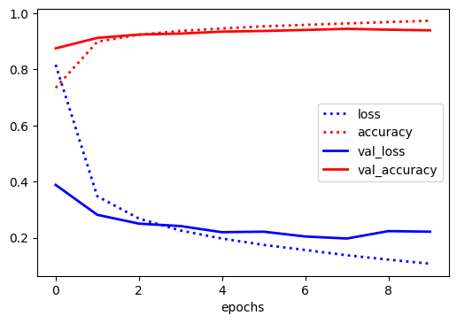

```
Model: "sequential_8"
_________________________________________________________________
Layer (type)                 Output Shape              Param #
=================================================================
vgg16 (Model)                (None, 1, 1, 512)         14714688
_________________________________________________________________
flatten_2 (Flatten)          (None, 512)               0
_________________________________________________________________
dense_27 (Dense)             (None, 256)               131328
_________________________________________________________________
dropout_3 (Dropout)          (None, 256)               0
_________________________________________________________________
dense_28 (Dense)             (None, 10)                2570
=================================================================
Total params: 14,848,586
Trainable params: 14,588,426
Non-trainable params: 260,160
_________________________________________________________________
None
def build_model_4_1():
  # set if you want to train the convolutional base
  train_base=True

  conv_base = VGG16(weights='imagenet', include_top=False, input_shape=(32, 32, 3))

  # unfreezing last convolutional layers
  if train_base:
    conv_base.trainable = True
    set_trainable = False

    for layer in conv_base.layers:
      if layer.name == 'block3_conv1':
          set_trainable = True
      if set_trainable:
          layer.trainable = True
      else:
          layer.trainable = False

  else:
    conv_base.trainable = False

  # print(conv_base.summary())

  model = models.Sequential()
  model.add(conv_base)
  model.add(layers.Flatten())
  model.add(layers.Dense(256, activation='relu'))
  model.add(layers.Dropout(0.5))
  model.add(layers.Dense(10, activation='sigmoid'))

  # print(model.summary())

  sgd = tf.keras.optimizers.SGD(lr=0.001, momentum=0.9, nesterov=True)

  model.compile(loss='categorical_crossentropy',
              optimizer=sgd,
              metrics=['accuracy'])

  return model
```

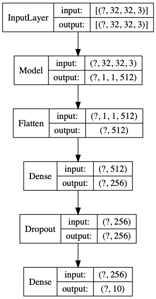

#### Answer 4.2, Embeddings (5p)

- Generate embeddings with the trained convolutional part of model_4_1 (without the dense layer)
- Embed the training and test data and store them to disk
- Build and evaluate a pipeline on the embedded data
  - Check if pipeline makes sense (e.g. use models that can handle many dimensions)
- Describe what you did and what you observed (max 800 chars).
  - Consider different models, preprocessing, tuning, etc.
  - Check performance (see original Submission.html) when in doubt. We did not run all the evaluations because it takes too long, and the output is ill-defined.

[output not shown]

```
Running time: 10.66 seconds
Last modified: May 26, 2020
scikit-learn version: 0.23.1
```